# Pre-Proccessing Data

```r
par(par0)
```

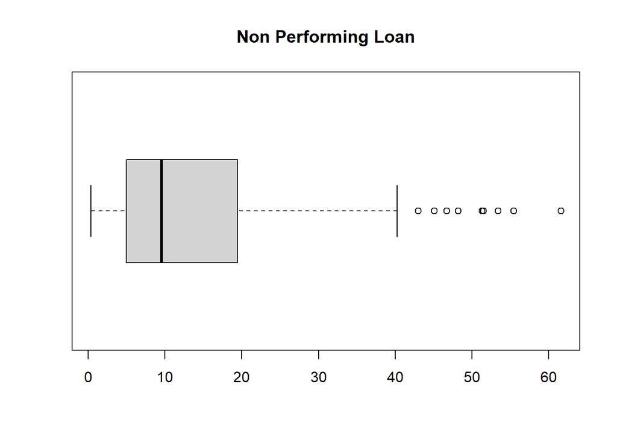

```r
# Non Performing Loan
boxplot(bpr$Non.Performing.Loan, main="Non Performing Loan", horizontal=T)
```

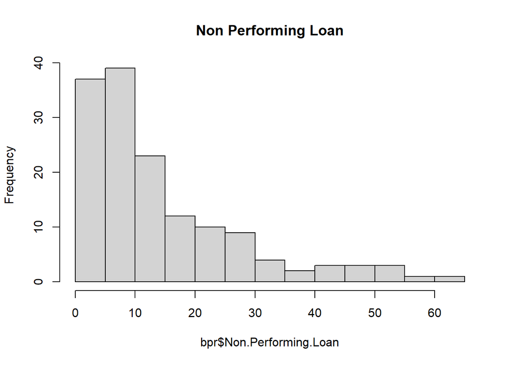

```r
hist(bpr$Non.Performing.Loan, main="Non Performing Loan", breaks=20)
```

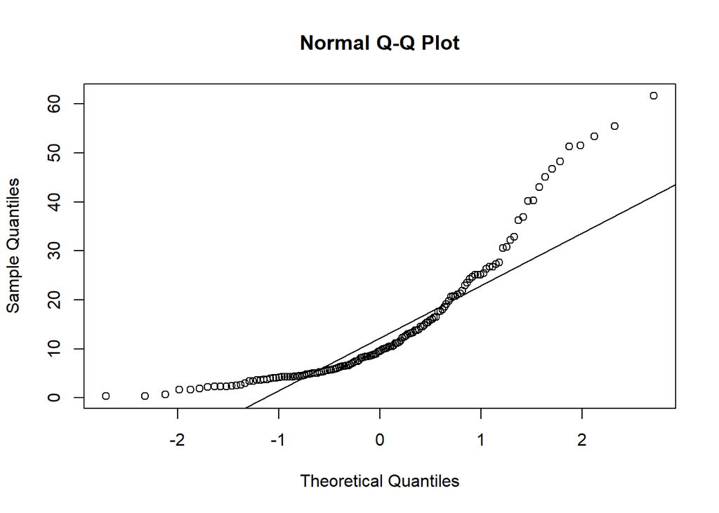

```r
# Membuat QQ plot
qqnorm(bpr$Non.Performing.Loan)
qqline(bpr$Non.Performing.Loan)
```

## 4.1 Fungsi WInsorized

Fungsi WInsorized digunakan untuk mengganti nilai-nilai outlier dengan nilai “batas bawah” untuk sebelah kiri dan nilai “batas atas” untuk sebelah kanan

```r
winval <- function (x, tr = 0.2)
{
    y <- sort(x)
    n <- length(x)

    # menentukan indeks batas bawah
    ibot <- floor(tr * n) + 1

    # menentukan indeks batas atas
    itop <- length(x) - ibot + 1

    xbot <- y[ibot] # mengambil nilai pada indeks batas bawah
    xtop <- y[itop] # mengambil nilai pada indeks batas atas

    #(data dengan nilai kurang dari xbot akan diganti dengan data xbot)
    winval <- ifelse(x <= xbot, xbot, x)

    #(data dengan nilai lebih dari xtop akan diganti dengan xtop)
    winval <- ifelse(winval >= xtop, xtop, winval)
    winval
}


winmean <- function (x, tr = 0.2)
{
    winmean <- mean(winval(x, tr))
    winmean
}

winvar <- function (x, tr = 0.2)
{
    winvar <- var(winval(x, tr))
    winvar
}

winse <- function (x, tr = 0.2)
{
  n = length(x)
  h = n - 2 * floor(tr * n)
  top = (n - 1) * sqrt(winvar(x, tr = tr))
  bot = (h - 1) * sqrt(n)
  se = top/bot
  se
}
```

```r
x <- bpr$Non.Performing.Loan

x.bar <- mean(x)                   # rataan sample
x.med <- median(x)                 # median sample
x.bar.tr.50 <- mean(x,trim=.5)      # rataan terpangkas 50% (median)
x.bar.tr.20 <- mean(x,trim=.2)      # rataan terpangkas 20%
x.bar.tr.10 <- mean(x,trim=.1)      # rataan terpangkas 10%
x.winmean <- winmean(x)             # winsorized mean 20%
x.winmean.10 <- winmean(x, tr=0.1)  # winsorized mean 10%

cat("Mean   :", x.bar, "\n")
```

```
## Mean   : 14.17514
```

```r
cat("Median :", x.med, "\n\n")
```

```
## Median : 9.568333
```

```r
cat("Tr. mean (50%)  :", x.bar.tr.50, "\n")
```

```
## Tr. mean (50%)  : 9.568333
```

```r
cat("Tr. mean (20%)  :", x.bar.tr.20, "\n")
```

```
## Tr. mean (20%)  : 10.71661
```

```r
cat("Tr. mean (10%)  :", x.bar.tr.10, "\n")
```

```
## Tr. mean (10%)  : 11.88604
```

```r
cat("win. mean (20%) :", x.winmean, "\n")
```

```
## win. mean (20%) : 11.86249
```

```r
cat("win. mean (10%) :", x.winmean.10, "\n\n")
```

```
## win. mean (10%) : 13.00679
```

```r
cat("Quatile :", quantile(x))
```

```
## Quatile : 0.3433333 4.973333 9.568333 19.4375 61.61
```

```r
IQR(x)
```

```
## [1] 14.46417
```

```r
mad(x)
```

```
## [1] 7.894845
```

```r
winvar(x)            # winsorized variance .20
```

```
## [1] 52.02483
```

```r
winvar(x, tr=0.1)    # winsorized variance .10
```

```
## [1] 91.66518
```

## 4.2 Selang Kepercayaan

```r
trimse <- function (x, tr = 0.2)
{
   trimse <- sqrt(winvar(x, tr))/((1 - 2 * tr) * sqrt(length(x)))
   trimse
}

se.med <- sqrt((pi/2)*(mad(x)^2/length(x)))  # s.e  median
```

```r
# SK 95% Mean
ci.mean <- t.test(x)$conf.int
ci.level <- attr(t.test(x)$conf.int, "conf.level")

# SK 95% Trimmed Mean
ci.tr.mean <- c(mean(x,trim=.2)-qnorm(0.975)*trimse(x),mean(x,trim=.2)+qnorm(0.975)*trimse(x))

# SK 95% Median
ci.med <- c(median(x)-qnorm(0.975)*se.med,median(x)+qnorm(0.975)*se.med)

# SK 95% Winsorized Mean
ci.win.mean <- c(winmean(x)-qnorm(0.975)*winse(x),winmean(x)+qnorm(0.975)*winse(x))

cat("Selang Kepercayaan     : ", ci.level, "\n\n")
```

```
## Selang Kepercayaan     :  0.95
```

```r
cat("Mean      : ", ci.mean, "\n")
```

```
## Mean      :  12.0626 16.28767
```

```r
cat("Tr. Mean  : ", ci.tr.mean, "\n")
```

```
## Tr. Mean  :  8.773294 12.65993
```

```r
cat("Median    : ", ci.med, "\n")
```

```
## Median    :  7.968801 11.16787
```

```r
cat("Win. Mean : ", ci.win.mean, "\n utk 20% (default di fungsi kita)")
```

```
## Win. Mean :  9.928011 13.79698
##  utk 20% (default di fungsi kita)
```

```r
library(MASS)
```

```r
# M-ESTIMATOR
x <- bpr$Non.Performing.Loan

hub.1 <- hubers(x)
hub.1$mu
```

```
## [1] 12.27906
```

```r
hub.1$s
```

```
## [1] 9.795196
```

```r
hub.2 <- hubers(x, k=1.345)
hub.2$mu
```

```
## [1] 11.98978
```

```r
hub.2$s
```

```
## [1] 9.686614
```

```r
hub.3 <- hubers(x,mu=median(x))
hub.3$mu
```

```
## [1] 9.568333
```

```r
hub.3$s
```

```
## [1] 8.719008
```

```r
hub.4 <- hubers(x,s=1)
hub.4$mu
```

```
## [1] 9.54636
```

```r
hub.4$s
```

```
## [1] 1
```

# 5 Outlier: Data Handphone

```r
data(phones)
str(phones)
```

```
## List of 2
##  $ year : num [1:24] 50 51 52 53 54 55 56 57 58 59 ...
##  $ calls: num [1:24] 4.4 4.7 4.7 5.9 6.6 7.3 8.1 8.8 10.6 12 ...
```

```r
data.frame(phones)
```

```
##    year calls
## 1    50   4.4
## 2    51   4.7
## 3    52   4.7
## 4    53   5.9
## 5    54   6.6
## 6    55   7.3
## 7    56   8.1
## 8    57   8.8
## 9    58  10.6
## 10   59  12.0
## 11   60  13.5
## 12   61  14.9
## 13   62  16.1
## 14   63  21.2
## 15   64 119.0
## 16   65 124.0
## 17   66 142.0
## 18   67 159.0
## 19   68 182.0
## 20   69 212.0
## 21   70  43.0
## 22   71  24.0
## 23   72  27.0
## 24   73  29.0
```

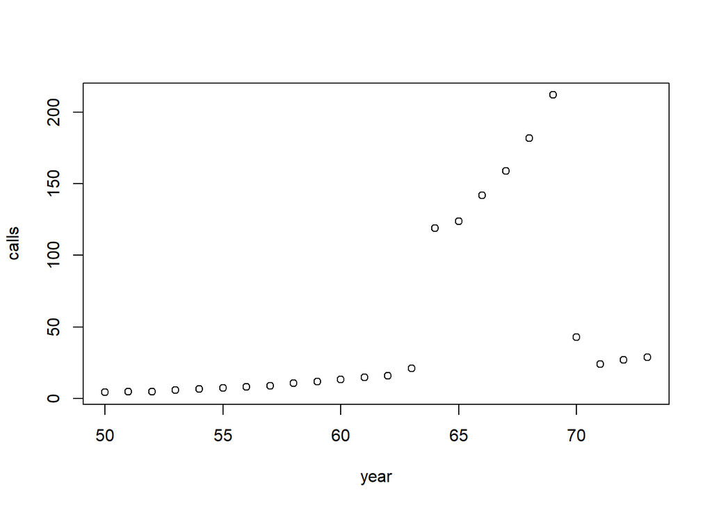

```r
attach(phones)
plot(year,calls)
```

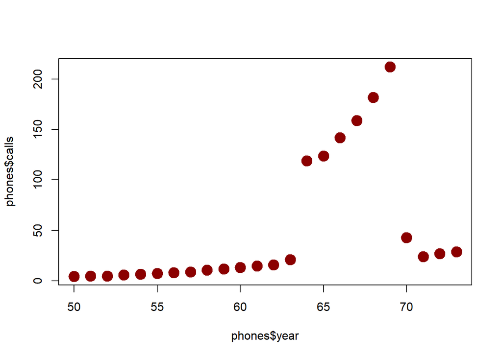

```r
plot(phones$year,phones$calls, pch=19, cex=2, col="darkred")
```

```r
fit.ols <- lm(calls~year, data=phones) # ols = ordinary linear square
              # calls sebagai peubah y dan year sebgai peubah x
summary(fit.ols)
```

```
##
## Call:
## lm(formula = calls ~ year, data = phones)
##
## Residuals:
##    Min     1Q Median     3Q    Max
## -78.97 -33.52 -12.04  23.38 124.20
##
## Coefficients:
##             Estimate Std. Error t value Pr(>|t|)
## (Intercept) -260.059    102.607  -2.535   0.0189 *
## year           5.041      1.658   3.041   0.0060 **
## ---
## Signif. codes:  0 '***' 0.001 '**' 0.01 '*' 0.05 '.' 0.1 ' ' 1
##
## Residual standard error: 56.22 on 22 degrees of freedom
## Multiple R-squared:  0.2959, Adjusted R-squared:  0.2639
## F-statistic: 9.247 on 1 and 22 DF,  p-value: 0.005998
```

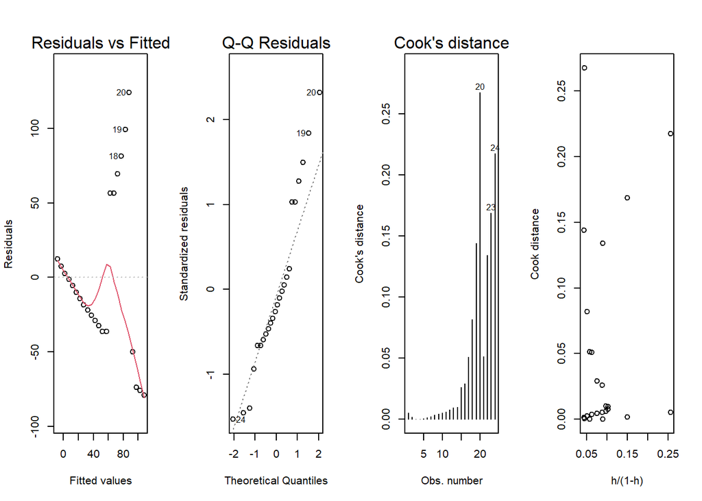

```r
par(mfrow=c(1,4))
plot(fit.ols,1:2)
plot(fit.ols,4)
abline(fit.ols$coef)

hmat.p <- hat(model.matrix(fit.ols))
h.phone <- hat(hmat.p)
cook.d <- cooks.distance(fit.ols)
plot(h.phone/(1-h.phone),cook.d,xlab="h/(1-h)",ylab="Cook distance")
```

```r
fit.hub <- rlm(calls~year,maxit=50, data=phones)
summary(fit.hub,cor=F)
```

```
##
## Call: rlm(formula = calls ~ year, data = phones, maxit = 50)
## Residuals:
##     Min      1Q  Median      3Q     Max
## -18.314  -5.953  -1.681  26.460 173.769
##
## Coefficients:
##             Value     Std. Error t value
## (Intercept) -102.6222   26.6082    -3.8568
## year           2.0414    0.4299     4.7480
##
## Residual standard error: 9.032 on 22 degrees of freedom
```

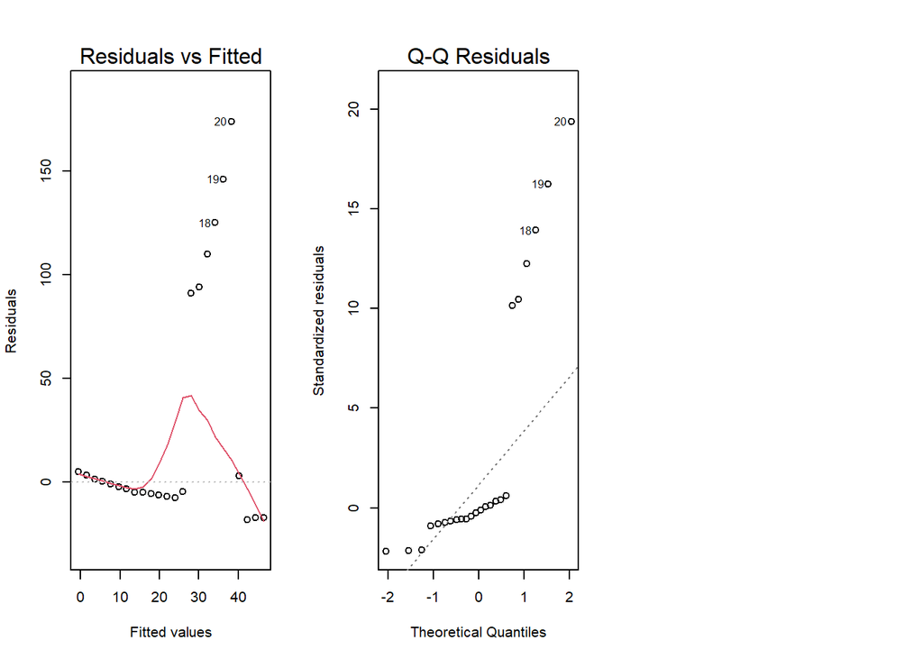

```r
par(mfrow=c(1,3))
plot(fit.hub,1)
plot(fit.hub,2)
abline(fit.hub$coef)
```

```r
fit.hub2 <- rlm(calls~year,scale.est="proposal 2", data=phones)
summary(fit.hub2,cor=F)
```

```
##
## Call: rlm(formula = calls ~ year, data = phones, scale.est = "proposal 2")
## Residuals:
##    Min     1Q Median     3Q    Max
## -68.15 -29.46 -11.52  22.74 132.67
##
## Coefficients:
##             Value     Std. Error t value
## (Intercept) -227.9250  101.8740    -2.2373
## year           4.4530    1.6461     2.7052
##
## Residual standard error: 57.25 on 22 degrees of freedom
```

```r
fit.lms <- lqs(calls~year,method="lms", data=phones)

fit.lms
```

```
## Call:
## lqs.formula(formula = calls ~ year, data = phones, method = "lms")
##
## Coefficients:
## (Intercept)         year
##     -55.947        1.155
##
## Scale estimates 0.9377 0.9095
```

```r
fit.lts <- lqs(calls~year,method="lts", data=phones)
fit.lts
```

```
## Call:
## lqs.formula(formula = calls ~ year, data = phones, method = "lts")
##
## Coefficients:
## (Intercept)         year
##     -56.162        1.159
##
## Scale estimates 1.249 1.131
```

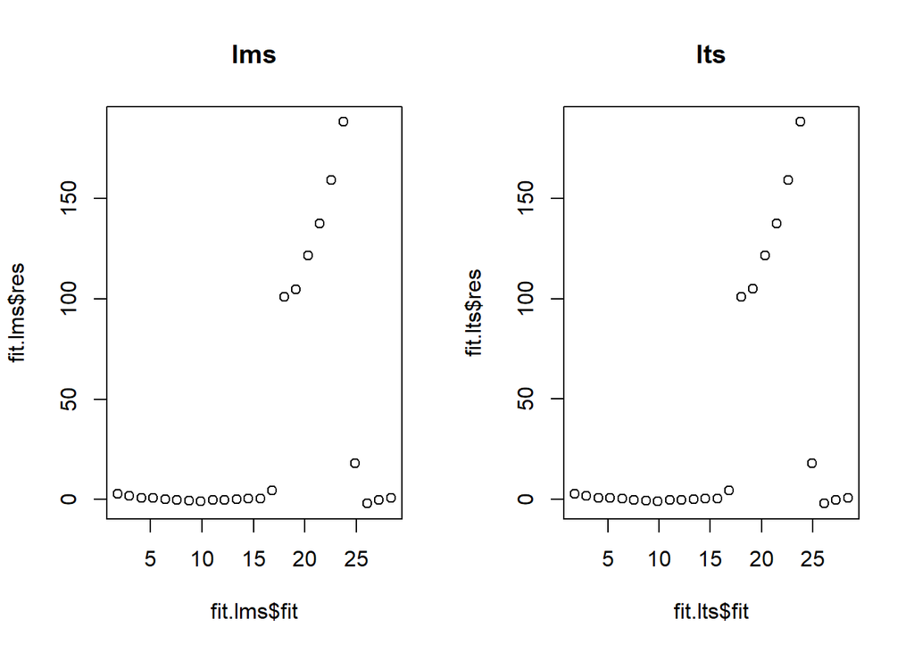

```r
par(mfrow=c(1,2))
plot(fit.lms$fit,fit.lms$res,main="lms")
plot(fit.lts$fit,fit.lts$res,main="lts")
```

```r
par(mfrow=c(1,1))
```

```r
data.frame(diabetes)
```

[output not shown]

[output cut: 1523 more lines]

# 6 Outlier: Data Pima Indian Diabetes

## 6.1 Pemeriksaan Data

```r
setwd("D:/Kuliah/Mat/TSA Kominfo/Praktikum")
diabetes <- read.csv("pima-indians-diabeter-database.csv", sep = ',')
library(ggplot2)
library(mlbench) # data pima Indian Dataset
library(cowplot) # menampilkan plot dalam bentuk Grid
library(caret) # features scaling
str(diabetes)
```

```
## 'data.frame':    768 obs. of  9 variables:
##  $ Pregnancies             : int  6 1 8 1 0 5 3 10 2 8 ...
##  $ Glucose                 : int  148 85 183 89 137 116 78 115 197 125 ...
##  $ BloodPressure           : int  72 66 64 66 40 74 50 0 70 96 ...
##  $ SkinThickness           : int  35 29 0 23 35 0 32 0 45 0 ...
##  $ Insulin                 : int  0 0 0 94 168 0 88 0 543 0 ...
##  $ BMI                     : num  33.6 26.6 23.3 28.1 43.1 25.6 31 35.3 30.5 0 ...
##  $ DiabetesPedigreeFunction: num  0.627 0.351 0.672 0.167 2.288 ...
##  $ Age                     : int  50 31 32 21 33 30 26 29 53 54 ...
##  $ Outcome                 : int  1 0 1 0 1 0 1 0 1 1 ...
```

```r
head(diabetes)
```

```
##   Pregnancies Glucose BloodPressure SkinThickness Insulin  BMI
## 1           6     148            72            35       0 33.6
## 2           1      85            66            29       0 26.6
## 3           8     183            64             0       0 23.3
## 4           1      89            66            23      94 28.1
## 5           0     137            40            35     168 43.1
## 6           5     116            74             0       0 25.6
##   DiabetesPedigreeFunction Age Outcome
## 1                    0.627  50       1
## 2                    0.351  31       0
## 3                    0.672  32       1
## 4                    0.167  21       0
## 5                    2.288  33       1
## 6                    0.201  30       0
```

## 6.2 Ringkasan dan Sebaran Data

```r
dim(diabetes)
```

```
## [1] 768   9
```

```r
summary(diabetes)
```

```
##   Pregnancies        Glucose      BloodPressure    SkinThickness
##  Min.   : 0.000   Min.   :  0.0   Min.   :  0.00   Min.   : 0.00
##  1st Qu.: 1.000   1st Qu.: 99.0   1st Qu.: 62.00   1st Qu.: 0.00
##  Median : 3.000   Median :117.0   Median : 72.00   Median :23.00
##  Mean   : 3.845   Mean   :120.9   Mean   : 69.11   Mean   :20.54
##  3rd Qu.: 6.000   3rd Qu.:140.2   3rd Qu.: 80.00   3rd Qu.:32.00
##  Max.   :17.000   Max.   :199.0   Max.   :122.00   Max.   :99.00
##     Insulin           BMI        DiabetesPedigreeFunction      Age
##  Min.   :  0.0   Min.   : 0.00   Min.   :0.0780           Min.   :21.00
##  1st Qu.:  0.0   1st Qu.:27.30   1st Qu.:0.2437           1st Qu.:24.00
##  Median : 30.5   Median :32.00   Median :0.3725           Median :29.00
##  Mean   : 79.8   Mean   :31.99   Mean   :0.4719           Mean   :33.24
##  3rd Qu.:127.2   3rd Qu.:36.60   3rd Qu.:0.6262           3rd Qu.:41.00
##  Max.   :846.0   Max.   :67.10   Max.   :2.4200           Max.   :81.00
##     Outcome
##  Min.   :0.000
##  1st Qu.:0.000
##  Median :0.000
##  Mean   :0.349
##  3rd Qu.:1.000
##  Max.   :1.000
```

### 6.2.1 Jumlah Nilai NA

```
  dari summary di bawah, terlihat tidak terdapat data NA
```

```r
data.frame(colSums(is.na(diabetes)))
```

```
##                          colSums.is.na.diabetes..
## Pregnancies                                     0
## Glucose                                         0
## BloodPressure                                   0
## SkinThickness                                   0
## Insulin                                         0
## BMI                                             0
## DiabetesPedigreeFunction                        0
## Age                                             0
## Outcome                                         0
```

### 6.2.2 Jumlah Nilai 0

terlihat banyak kolom memiliki nilai 0 yang seharusnya tidak mungkin 0. Seperti glucose yang menunjukkan kadar gula atau pressure yang menunjukkan tekanan darah, serta kolom lainnya. Kondisi ini perlu ditangani karena merupakan informasi yang keliru.

```r
data.frame(colSums(diabetes==0))
```

```
##                          colSums.diabetes....0.
## Pregnancies                                 111
## Glucose                                       5
## BloodPressure                                35
## SkinThickness                               227
## Insulin                                     374
## BMI                                          11
## DiabetesPedigreeFunction                      0
## Age                                           0
## Outcome                                     500
```

### 6.2.3 Persentase Jumlah Nilai 0 di setiap kolom

```r
data.frame(round(colSums(diabetes==0)/nrow(diabetes), 4)*100)
```

```
##                          round.colSums.diabetes....0..nrow.diabetes...4....100
## Pregnancies                                                              14.45
## Glucose                                                                   0.65
## BloodPressure                                                             4.56
## SkinThickness                                                            29.56
## Insulin                                                                  48.70
## BMI                                                                       1.43
## DiabetesPedigreeFunction                                                  0.00
## Age                                                                       0.00
## Outcome                                                                  65.10
```

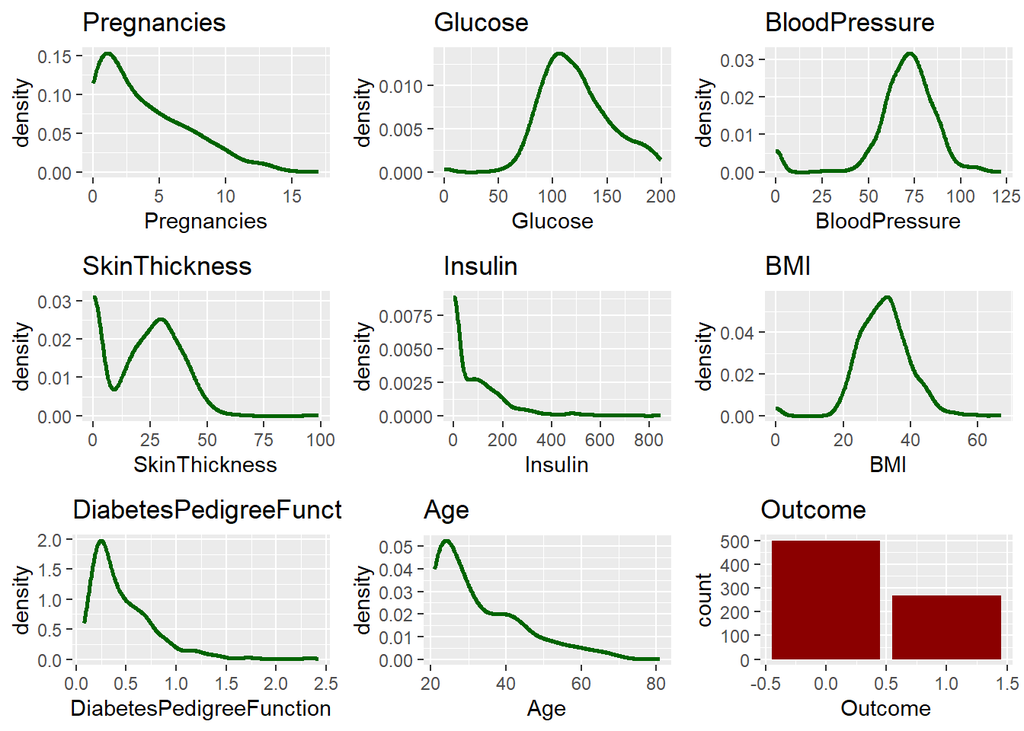

```r
library(gridExtra)
plot1 <- ggplot(diabetes, aes(x = Pregnancies)) +
         geom_density(lwd=1, color="darkgreen") +
         ggtitle("Pregnancies")
plot2 <- ggplot(diabetes, aes(x = Glucose)) +
         geom_density(lwd=1, color="darkgreen") +
         ggtitle("Glucose")
plot3 <- ggplot(diabetes, aes(x = BloodPressure)) +
         geom_density(lwd=1, color="darkgreen") +
         ggtitle("BloodPressure")
plot4 <- ggplot(diabetes, aes(x = SkinThickness)) +
         geom_density(lwd=1, color="darkgreen") +
         ggtitle("SkinThickness")
plot5 <- ggplot(diabetes, aes(x = Insulin)) +
         geom_density(lwd=1, color="darkgreen") +
         ggtitle("Insulin")
plot6 <- ggplot(diabetes, aes(x = BMI)) +
         geom_density(lwd=1, color="darkgreen") +
         ggtitle("BMI")
plot7 <- ggplot(diabetes, aes(x = DiabetesPedigreeFunction)) +
         geom_density(lwd=1, color="darkgreen") +
         ggtitle("DiabetesPedigreeFunction")
plot8 <- ggplot(diabetes, aes(x = Age)) +
         geom_density(lwd=1, color="darkgreen") +
         ggtitle("Age")
plot9 <- ggplot(diabetes, aes(x = Outcome)) +
         geom_bar(fill="darkred") +
         ggtitle("Outcome")

# Mengatur grid 3x3
grid.arrange(
  plot1, plot2, plot3,
  plot4, plot5, plot6,
  plot7, plot8, plot9,
  ncol = 3
)
```

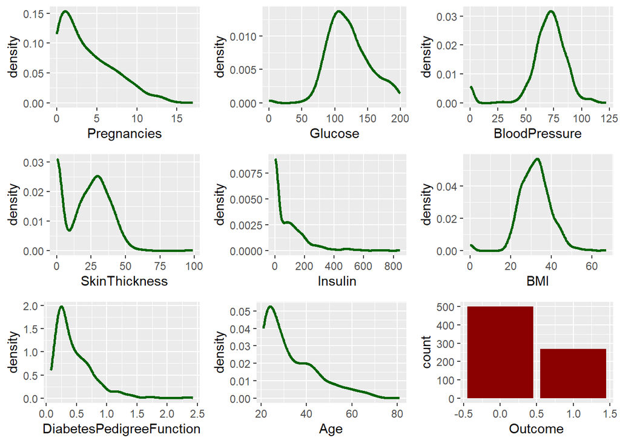

```r
plots <- lapply(names(diabetes), function(var_x){
  p <-
    ggplot(diabetes) +
    aes_string(var_x)

  if(var_x %in% names(diabetes)[1:8]) {
    p <- p + geom_density(lwd=1, color="darkgreen")

  } else if(var_x =="Outcome") {
    p <- p + geom_bar(fill="darkred")
  }

})
plot_grid(plotlist = plots)
```

## 6.3 Kolom Pregnancies

```r
library(ggplot2)
library(gridExtra)
```

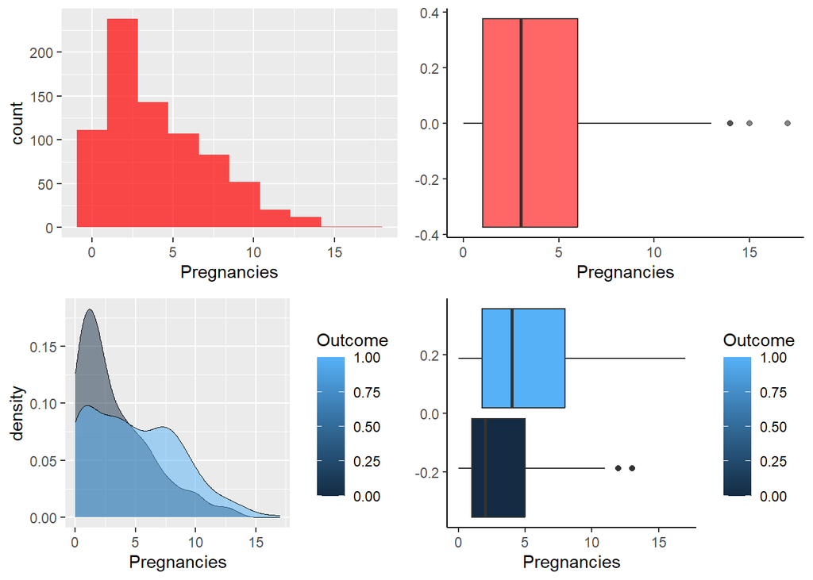

```r
plot1 <- ggplot(diabetes, aes(x = Pregnancies)) +
         geom_histogram(bins = 10, fill = "red", alpha = 0.7)
plot2 <- ggplot(diabetes, aes(x = Pregnancies)) +
         geom_boxplot(fill = "red", alpha=0.6) +theme_classic()
plot3 <- ggplot(diabetes, aes(x = Pregnancies, group=Outcome)) +
         geom_density(lwd=0.1, aes(fill=Outcome), alpha= 0.5)
plot4 <- ggplot(diabetes, aes(x = Pregnancies, group=Outcome)) +
         geom_boxplot(aes(fill = Outcome)) +theme_classic()

# Mengatur grid
grid.arrange(
  plot1, plot2, plot3, plot4, ncol = 2
)
```

```r
summary(diabetes$Pregnancies)
```

```
##    Min. 1st Qu.  Median    Mean 3rd Qu.    Max.
##   0.000   1.000   3.000   3.845   6.000  17.000
```

Sebaran nilai Pregnancies cenderung menjulur jauh ke kanan.

Menurut visualisasi boxplot, terdapat beberapa data outlier namun secara umum masih dalam batas yang wajar. Apalagi jika melihat boxplot antara Pregnancies dan Outcome sebaran data relatif cukup baik.

Namun jika ingin dilakukan penanganan maka terdapat beberapa alternatif:

- Menghapus data Outlier
- Mengganti data dengan mean/ median data yang tidak outlier
- Flooring & Capping: Mengganti data dengan nilai max teoritis (Misal Q1 - 1.5xIQR dan Q3 + 1.5xIQR)

### 6.3.1 Menghapus Data Outlier

Melihat dari boxplot tunggal, terdapat 3 titik data outlier, sedangkan jika melihat berdasarkan kelompok diabetes atau tidak maka terdapat dua outlier pada kelompok tidak diabetes. Misalkan kita menggunakan indikator dari boxplot tunggal, maka untuk menghapus data tersebut:

```r
q1 <-quantile(diabetes$Pregnancies, prob = 0.25, names = F)
q3 <-quantile(diabetes$Pregnancies, prob = 0.75, names = F)
IQR <- q3 - q1
max <- q3 + 1.5*IQR
```

```r
# Hapus data yang lebih besar dari max yaitu

# R base
(diabetes[diabetes$Pregnancies > max,])
```

```
##     Pregnancies Glucose BloodPressure SkinThickness Insulin  BMI
## 89           15     136            70            32     110 37.1
## 160          17     163            72            41     114 40.9
## 299          14     100            78            25     184 36.6
## 456          14     175            62            30       0 33.6
##     DiabetesPedigreeFunction Age Outcome
## 89                     0.153  43       1
## 160                    0.817  47       1
## 299                    0.412  46       1
## 456                    0.212  38       1
```

```r
# dplyr
#library(dplyr)
#(diabetes %>% filter(Pregnancies > max))
```

### 6.3.2 Mengganti dengan Mean/Median dari data yang tidak Outlier

```r
non.outlier <- diabetes[diabetes$Pregnancies <= max, "Pregnancies"]
mean.non <- mean(non.outlier)
med.non <- median(non.outlier)

# Update outlier data menggunakan mean atau median

# R base
diabetes$Pregnancies <- ifelse(diabetes$Pregnancies > max, med.non, diabetes$Pregnancies)

# dplyr
# diabetes <- diabetes %>% mutate(pregnant = ifelse(pregnant > max, med.non, pregnant))
```

### 6.3.3 Mengganti dengan Nilai Max dari data yang tidak Outlier

Sama seperti sebelumnya, cukup mengganti nilai outlier dengan nilai minimum/maksimum

```r
# Update outlier data menggunakan nilai max

# R base
# diabetes$Pregnancies <- ifelse(diabetes$Pregnancies > max, max,
#                              diabetes$Pregnancies)

# dplyr
# diabetes <- diabetes %>% mutate(pregnant = ifelse(pregnant > max, max, pregnant))
```

### 6.3.4 Plot Setelah Modifikasi

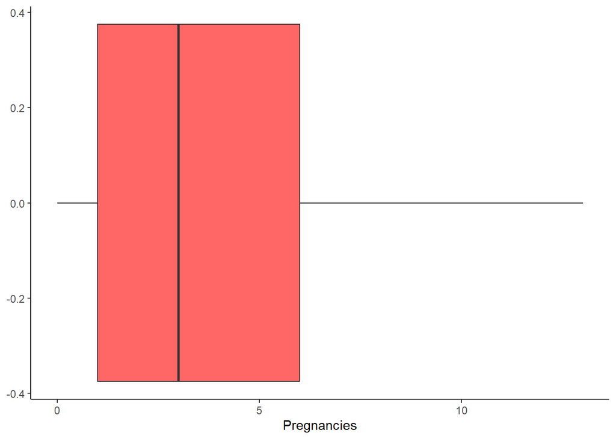

```r
pl2 <- ggplot(diabetes, aes(y=Pregnancies))
pl2 +
  geom_boxplot(fill="red", alpha=0.6) + coord_flip() + theme_classic()
```

## 6.4 Kolom Glucose

```r
summary(diabetes$Glucose)
```

```
##    Min. 1st Qu.  Median    Mean 3rd Qu.    Max.
##     0.0    99.0   117.0   120.9   140.2   199.0
```

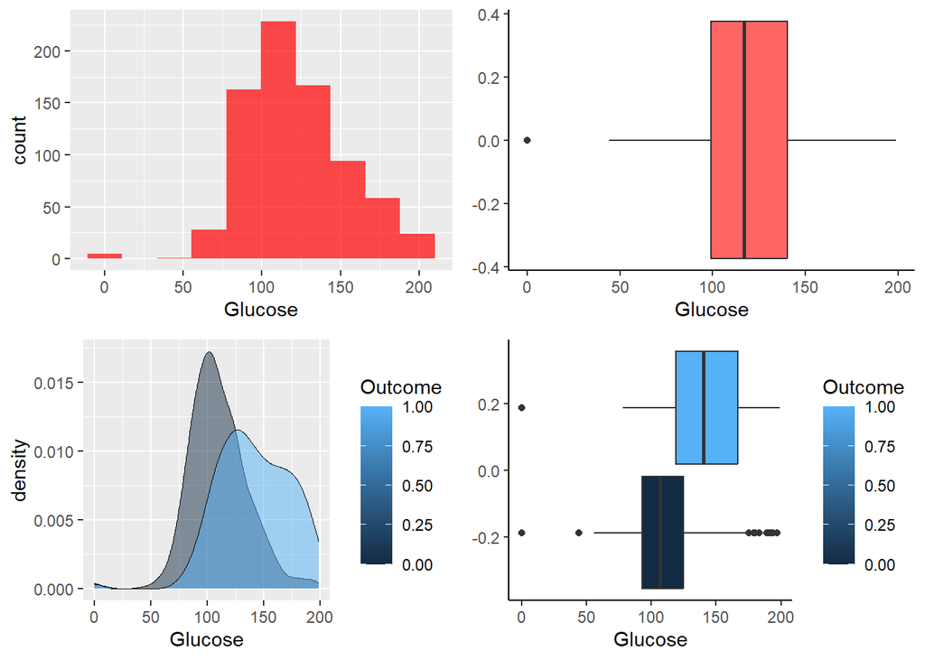

```r
plot1 <- ggplot(diabetes, aes(x = Glucose)) +
         geom_histogram(bins = 10, fill = "red", alpha = 0.7)
plot2 <- ggplot(diabetes, aes(x = Glucose)) +
         geom_boxplot(fill = "red", alpha=0.6) +theme_classic()
plot3 <- ggplot(diabetes, aes(x = Glucose, group=Outcome)) +
         geom_density(lwd=0.1, aes(fill=Outcome), alpha= 0.5)
plot4 <- ggplot(diabetes, aes(x = Glucose, group=Outcome)) +
         geom_boxplot(aes(fill = Outcome)) +theme_classic()

# Mengatur grid
grid.arrange(
  plot1, plot2, plot3, plot4, ncol = 2
)
```

Pada kolom ini sebaran data relatif simetris, dan secara umum tidak terdapat data outlier kecuali pada data bernilai 0.

Nilai Glucose menunjukkan kadar gula dalam darah, sehingga tidak mungkin bernilai 0. Perlu dicek juga apakah terdapat nilai-nilai lainnya yang tidak masuk akal (misalkan menurut Dokter).Namun pada contoh ini kita hanya akan fokus pada nilai 0 saja, kita anggap nilai lainnya masih masuk dalam rentang nilai yang memungkinkan.

Cek jumlah data bernilai 0:

```r
length(which(diabetes$Glucose == 0))
```

```
## [1] 5
```

Terdapat 5 data yang memiliki nilai Glucose = 0 yang perlu ditangani. Jumlah ini relatif sedikit jadi dapat saja kita 5 baris ini atau alternatif lain kita amputasi misal dengan mean atau median.

### 6.4.1 Menghapus Data

```r
# R base
# diabetes <- diabetes[diabetes$Glucose > 0,]

# dplyr
#diabetes <- diabetes %>% filter(Glucose > 0)
```

### 6.4.2 Mengganti dengan Nilai Mean atau Median

Perlu diperhatikan, karena data bernilai 0 (bukan NA) maka perlu berhati-hati khususnya dalam menghitung mean.

Jika data bernilai NA, penghitungan mean dapat langsung dilakukan pada seluruh data, karena nilai NA akan diabaikan. Namun jika data 0 maka nilai tersebut akan dimasukkan dalam penghitungan rata-rata. Oleh karena itu, perlu difilter terlebih dahulu data yang tidak bernilai 0.

Pemilihan mean biasanya untuk data yang memiliki sebaran simetris, sementara untuk data dengan sebaran yang menjulur dapat menggunakan nilai median.

Melihat dari boxplot, tampat terdapat perbedaan sebaran nilai Glucose antara yang terkena diabetes dan yang tidak. Penderita Diabetes cenderung memiliki nilai Glucose yang lebih tinggi dibandingkan yang bukan penderita diabetes.

Opsi yang cocok adalah menggunakan mean atau median per kelompok. Data Glucose bernilai 0 mengacu pada kelompok diabetes diganti dengan mean atau median pada kelompok tersebut begitu pula sebaliknya.

```r
# Mengambil data glucose yang tidak bernilai 0
glucose.pos <- diabetes[(diabetes$Glucose != 0) & (diabetes$Outcome == "1"), "Glucose"]
glucose.neg <- diabetes[(diabetes$Glucose != 0) & (diabetes$Outcome == "0"), "Glucose"]

# Menghitung mean glucose masing-masing kelompok
med.gluc.pos <- median(glucose.pos)
med.gluc.neg <- median(glucose.neg)

# Mengganti nilai 0 dengan mean

# R base
diabetes$Glucose <- ifelse(diabetes$Glucose == 0,
                           ifelse(diabetes$Outcome == "1", med.gluc.pos, med.gluc.neg),
                           diabetes$Glucose)

# dplyr
# diabetes <- diabetes %>% mutate(glucose = ifelse(glucose == 0,
#                                                 ifelse(diabetes=="pos",
# med.gluc.pos, med.gluc.neg),
#                                                 glucose))
```

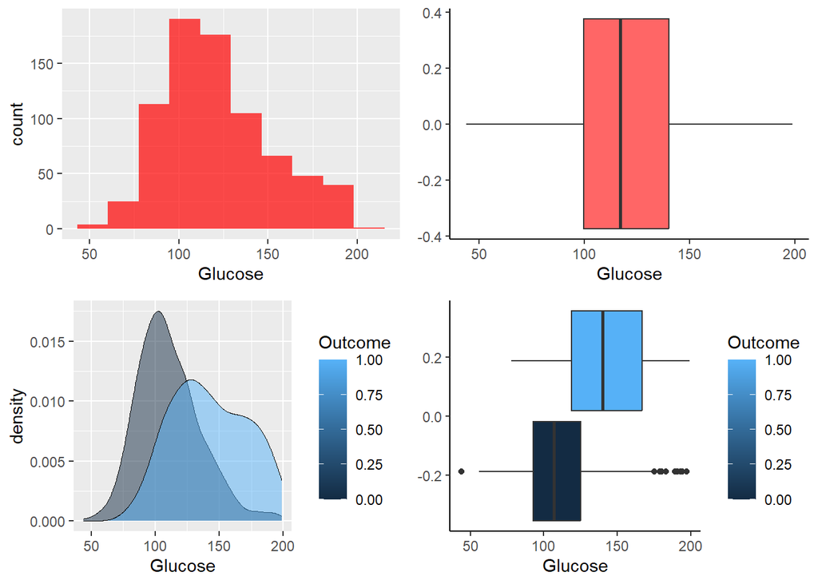

```r
plot1 <- ggplot(diabetes, aes(x = Glucose)) +
         geom_histogram(bins = 10, fill = "red", alpha = 0.7)
plot2 <- ggplot(diabetes, aes(x = Glucose)) +
         geom_boxplot(fill = "red", alpha=0.6) +theme_classic()
plot3 <- ggplot(diabetes, aes(x = Glucose, group=Outcome)) +
         geom_density(lwd=0.1, aes(fill=Outcome), alpha= 0.5)
plot4 <- ggplot(diabetes, aes(x = Glucose, group=Outcome)) +
         geom_boxplot(aes(fill = Outcome)) +theme_classic()

# Mengatur grid
grid.arrange(
  plot1, plot2, plot3, plot4, ncol = 2
)
```

```r
summary(diabetes$Glucose)
```

```
##    Min. 1st Qu.  Median    Mean 3rd Qu.    Max.
##   44.00   99.75  117.00  121.68  140.25  199.00
```

## 6.5 Kolom Blood Pressure

Kolom BloodPressure berisi data tekanan darah yang memuat nilai 0 (tidak mungkin terjadi)

Selain itu terdapat nilai-nilai outlier di kedua sisinya.

```r
summary(diabetes$BloodPressure)
```

```
##    Min. 1st Qu.  Median    Mean 3rd Qu.    Max.
##    0.00   62.00   72.00   69.11   80.00  122.00
```

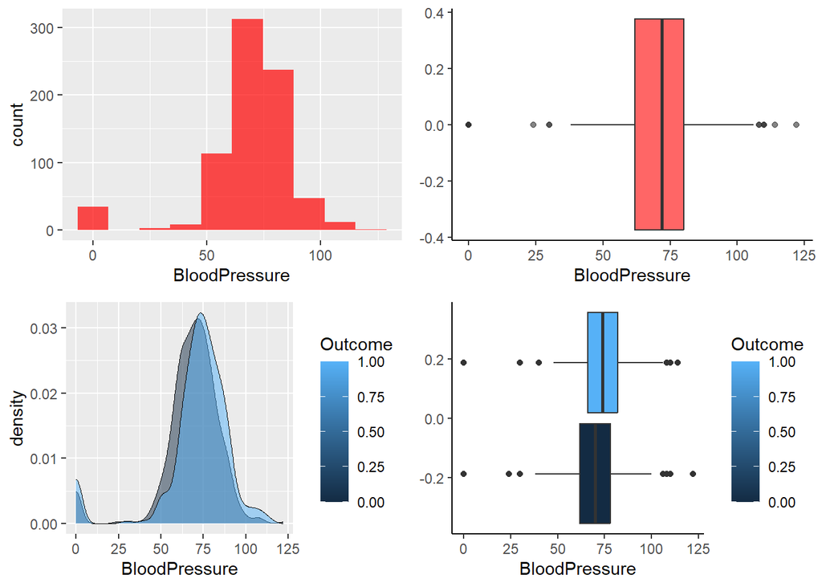

```r
plot1 <- ggplot(diabetes, aes(x = BloodPressure)) +
         geom_histogram(bins = 10, fill = "red", alpha = 0.7)
plot2 <- ggplot(diabetes, aes(x = BloodPressure)) +
         geom_boxplot(fill = "red", alpha=0.6) +theme_classic()
plot3 <- ggplot(diabetes, aes(x = BloodPressure, group=Outcome)) +
         geom_density(lwd=0.1, aes(fill=Outcome), alpha= 0.5)
plot4 <- ggplot(diabetes, aes(x = BloodPressure, group=Outcome)) +
         geom_boxplot(aes(fill = Outcome)) +theme_classic()

# Mengatur grid
grid.arrange(
  plot1, plot2, plot3, plot4, ncol = 2
)
```

### 6.5.1 Data bernilai 0

```r
length(which(diabetes$BloodPressure == 0))
```

```
## [1] 35
```

```r
library(dplyr)
zero.BloodPressure <- diabetes %>%
  filter(BloodPressure == 0) %>%
  group_by(Outcome) %>%
  summarise(count = length(BloodPressure))
zero.BloodPressure
```

```
## # A tibble: 2 × 2
##   Outcome count
##     <int> <int>
## 1       0    19
## 2       1    16
```

Pada data BloodPressure terindikasi terdapat beberapa amatan outlier, dapat pula dilakukan penanganan seperti pada bagian sebelumnya (pregnant). Namun di sini tidak akan dilakukan penanganan.

### 6.5.2 Mengganti nilai 0 dengan Nilai Mean

```r
# Mengambil data BloodPressure yang tidak bernilai 0
BloodPressure <- diabetes[diabetes$BloodPressure != 0, "BloodPressure"]

# Menghitung mean pressure
mean.BloodPressure <- mean(diabetes$BloodPressure)

# Mengganti nilai 0 dengan mean

# R base
diabetes$BloodPressure <- ifelse(diabetes$BloodPressure == 0, mean.BloodPressure, diabetes$BloodPressure)

# dplyr
# diabetes <- diabetes %>% mutate(pressure = ifelse(pressure == 0, mean.pressure, pressure))
```

### 6.5.3 Plot Setelah Imputasi

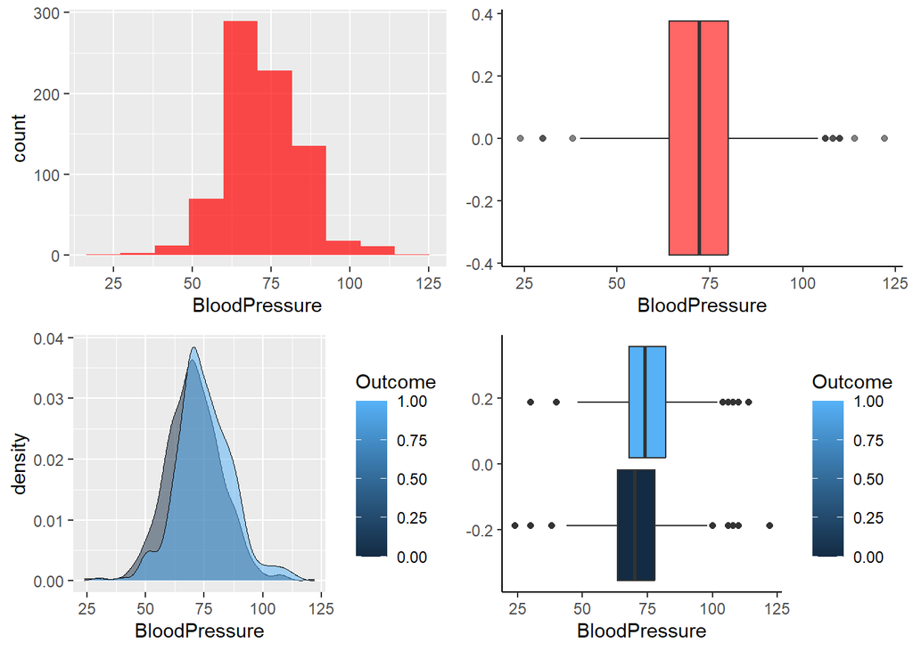

```r
plot1 <- ggplot(diabetes, aes(x = BloodPressure)) +
         geom_histogram(bins = 10, fill = "red", alpha = 0.7)
plot2 <- ggplot(diabetes, aes(x = BloodPressure)) +
         geom_boxplot(fill = "red", alpha=0.6) +theme_classic()
plot3 <- ggplot(diabetes, aes(x = BloodPressure, group=Outcome)) +
         geom_density(lwd=0.1, aes(fill=Outcome), alpha= 0.5)
plot4 <- ggplot(diabetes, aes(x = BloodPressure, group=Outcome)) +
         geom_boxplot(aes(fill = Outcome)) +theme_classic()

# Mengatur grid
grid.arrange(
  plot1, plot2, plot3, plot4, ncol = 2
)
```

## 6.6 Kolom Skin Thickness

Kolom SkinThickness menunjukkan ketebalan lipatan kulit(mm).

Data ini juga seharusnya tidak dapat bernilai 0.

```r
summary(diabetes$SkinThickness)
```

```
##    Min. 1st Qu.  Median    Mean 3rd Qu.    Max.
##    0.00    0.00   23.00   20.54   32.00   99.00
```

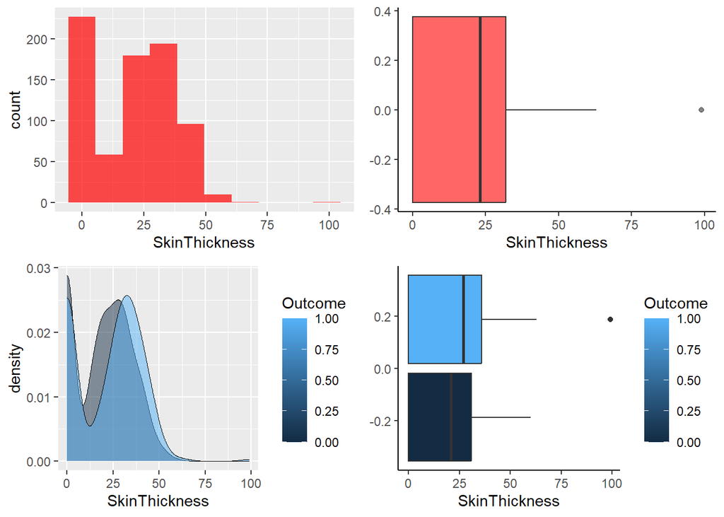

```r
plot1 <- ggplot(diabetes, aes(x = SkinThickness)) +
         geom_histogram(bins = 10, fill = "red", alpha = 0.7)
plot2 <- ggplot(diabetes, aes(x = SkinThickness)) +
         geom_boxplot(fill = "red", alpha=0.6) +theme_classic()
plot3 <- ggplot(diabetes, aes(x = SkinThickness, group=Outcome)) +
         geom_density(lwd=0.1, aes(fill=Outcome), alpha= 0.5)
plot4 <- ggplot(diabetes, aes(x = SkinThickness, group=Outcome)) +
         geom_boxplot(aes(fill = Outcome)) +theme_classic()

# Mengatur grid
grid.arrange(
  plot1, plot2, plot3, plot4, ncol = 2
)
```

```r
length(which(diabetes$SkinThickness == 0))
```

```
## [1] 227
```

```r
length(which(diabetes$SkinThickness == 0))/length(diabetes$SkinThickness)
```

```
## [1] 0.2955729
```

Jumlah data bernilai 0 untuk kolom SkinThickness cukup besar yaitu sekitar 30%.

Dapat dilakukan imputasi seperti kolom sebelumnya. Namun, jika dirasa terlalu banyak yang diimputasi mungkin sebaiknya kolom ini dapat dibuang dari model.

### 6.6.1 Menghapus Kolom SkinThickness

```r
diabetes$SkinThickness <- NULL
```

## 6.7 Kolom Insulin

Sama seperti kolom SkinThickness, kolom Insulin juga tidak mungkin bernilai 0. Namun pada data terdapat nilai 0 yang sangat banyak bahkan hampir 50%.

Oleh karena itu, penanganan yang paling tepat adalah membuang kolom tersebut dari model.

```r
summary(diabetes$Insulin)
```

```
##    Min. 1st Qu.  Median    Mean 3rd Qu.    Max.
##     0.0     0.0    30.5    79.8   127.2   846.0
```

```r
length(which(diabetes$Insulin == 0))
```

```
## [1] 374
```

```r
length(which(diabetes$Insulin == 0))/length(diabetes$Insulin)
```

```
## [1] 0.4869792
```

### 6.7.1 Menghapus kolom Insulin

```r
diabetes$Insulin <- NULL
```

## 6.8 Kolom BMI

```r
summary(diabetes$BMI)
```

```
##    Min. 1st Qu.  Median    Mean 3rd Qu.    Max.
##    0.00   27.30   32.00   31.99   36.60   67.10
```

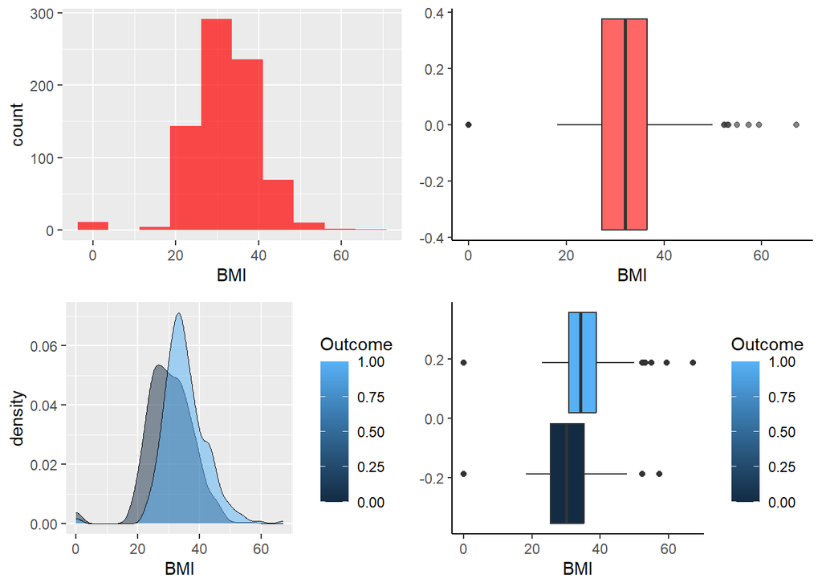

```r
plot1 <- ggplot(diabetes, aes(x = BMI)) +
         geom_histogram(bins = 10, fill = "red", alpha = 0.7)
plot2 <- ggplot(diabetes, aes(x = BMI)) +
         geom_boxplot(fill = "red", alpha=0.6) +theme_classic()
plot3 <- ggplot(diabetes, aes(x = BMI, group=Outcome)) +
         geom_density(lwd=0.1, aes(fill=Outcome), alpha= 0.5)
plot4 <- ggplot(diabetes, aes(x = BMI, group=Outcome)) +
         geom_boxplot(aes(fill = Outcome)) +theme_classic()

# Mengatur grid
grid.arrange(
  plot1, plot2, plot3, plot4, ncol = 2
)
```

```r
length(which(diabetes$BMI == 0))
```

```
## [1] 11
```

```r
length(which(diabetes$BMI == 0))/length(diabetes$BMI)
```

```
## [1] 0.01432292
```

### 6.8.1 Mengganti Nilai 0 dengan Nilai Mean

```r
# Mengambil data mass yang tidak bernilai 0
BMI <- diabetes[diabetes$BMI != 0, "BMI"]

# Menghitung mean mass
mean.BMI <- mean(diabetes$BMI)

# Mengganti nilai 0 dengan mean

# R base
diabetes$BMI <- ifelse(diabetes$BMI == 0, mean.BMI, diabetes$BMI)

# dplyr
# diabetes <- diabetes %>% mutate(mass = ifelse(mass == 0, mean.mass, mass))
```

### 6.8.2 Mengganti Nilai Data Outlier

Dalam kolom BMI ini, dianggap nilai BMI di atas (Q3 +1.5 IQR) merupakan nilai yang tidak masuk akal.

Maka akan dihapus amatan dengan BMI > 50 atau mengganti dengan nilai (Q3 + 1.5 IQR)

```r
q1 <- quantile(diabetes$BMI, probs=0.25, names=F)
q3 <- quantile(diabetes$BMI, probs=0.75, names=F)
IQR <- q3 - q1
max <- q3 + 1.5*IQR

# R base
diabetes$BMI <- ifelse(diabetes$BMI > max, max, diabetes$BMI)

# dplyr
# diabetes <- diabetes %>% mutate(mass = ifelse(mass > max, max, mass))
```

## 6.9 Setelah melakukan Imputasi Pada Kolom BMI

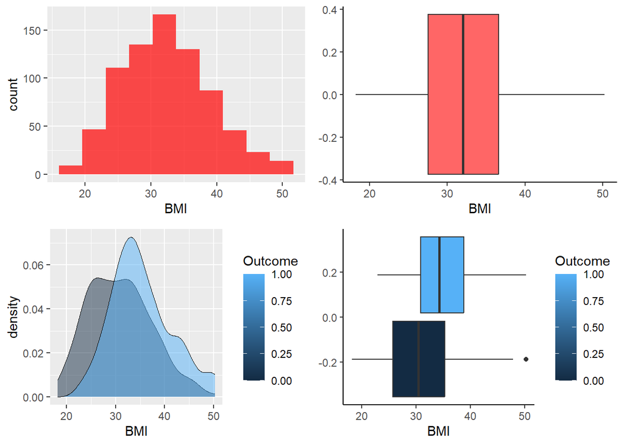

```r
plot1 <- ggplot(diabetes, aes(x = BMI)) +
         geom_histogram(bins = 10, fill = "red", alpha = 0.7)
plot2 <- ggplot(diabetes, aes(x = BMI)) +
         geom_boxplot(fill = "red", alpha=0.6) +theme_classic()
plot3 <- ggplot(diabetes, aes(x = BMI, group=Outcome)) +
         geom_density(lwd=0.1, aes(fill=Outcome), alpha= 0.5)
plot4 <- ggplot(diabetes, aes(x = BMI, group=Outcome)) +
         geom_boxplot(aes(fill = Outcome)) +theme_classic()

# Mengatur grid
grid.arrange(
  plot1, plot2, plot3, plot4, ncol = 2
)
```

## 6.10 Kolom Diabetes Pedigree Function

```r
summary(diabetes$DiabetesPedigreeFunction)
```

```
##    Min. 1st Qu.  Median    Mean 3rd Qu.    Max.
##  0.0780  0.2437  0.3725  0.4719  0.6262  2.4200
```

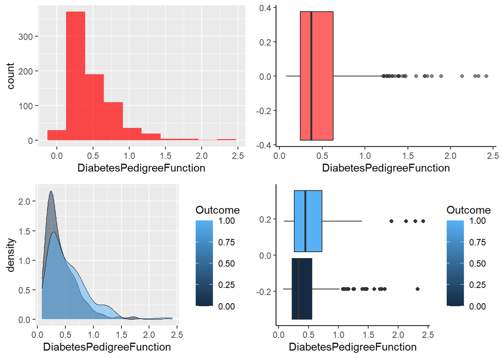

```r
plot1 <- ggplot(diabetes, aes(x = DiabetesPedigreeFunction)) +
         geom_histogram(bins = 10, fill = "red", alpha = 0.7)
plot2 <- ggplot(diabetes, aes(x = DiabetesPedigreeFunction)) +
         geom_boxplot(fill = "red", alpha=0.6) +theme_classic()
plot3 <- ggplot(diabetes, aes(x = DiabetesPedigreeFunction, group=Outcome)) +
         geom_density(lwd=0.1, aes(fill=Outcome), alpha= 0.5)
plot4 <- ggplot(diabetes, aes(x = DiabetesPedigreeFunction, group=Outcome)) +
         geom_boxplot(aes(fill = Outcome)) +theme_classic()

# Mengatur grid
grid.arrange(
  plot1, plot2, plot3, plot4, ncol = 2
)
```

```r
length(which(diabetes$DiabetesPedigreeFunction == 0))
```

```
## [1] 0
```

Untuk melakukan penanganan outlier dapat menggunakan cara seperti sebelumnya. Namun pada kolom Diabetes Pedigree Function ini akan dibiarkan, karena nilai-nilai masih masuk dalam rentang nilai yang memungkinkan.

## 6.11 Kolom Age

```r
summary(diabetes$Age)
```

```
##    Min. 1st Qu.  Median    Mean 3rd Qu.    Max.
##   21.00   24.00   29.00   33.24   41.00   81.00
```

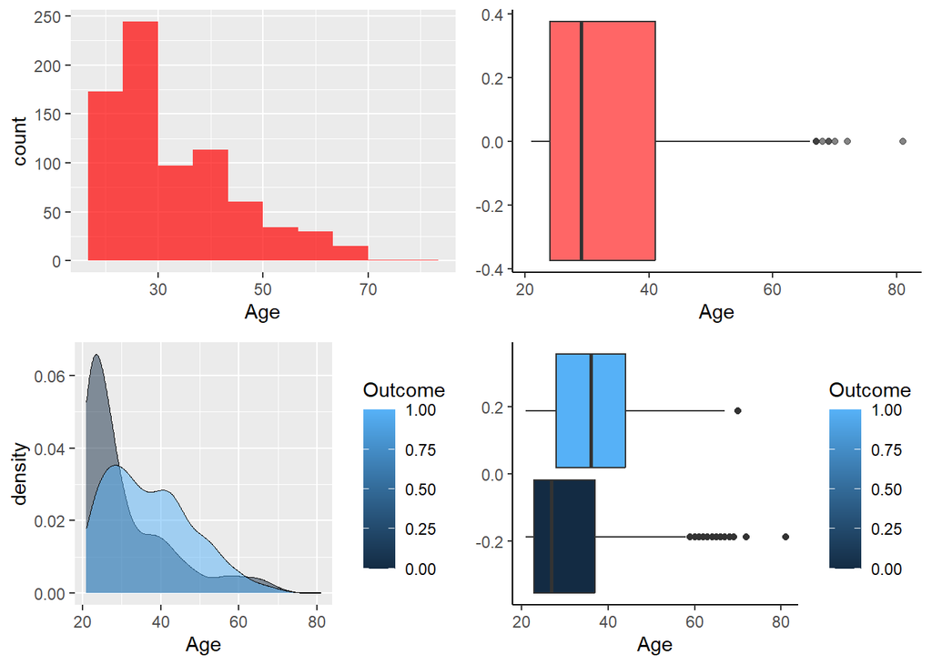

```r
plot1 <- ggplot(diabetes, aes(x = Age)) +
         geom_histogram(bins = 10, fill = "red", alpha = 0.7)
plot2 <- ggplot(diabetes, aes(x = Age)) +
         geom_boxplot(fill = "red", alpha=0.6) +theme_classic()
plot3 <- ggplot(diabetes, aes(x = Age, group=Outcome)) +
         geom_density(lwd=0.1, aes(fill=Outcome), alpha= 0.5)
plot4 <- ggplot(diabetes, aes(x = Age, group=Outcome)) +
         geom_boxplot(aes(fill = Outcome)) +theme_classic()

# Mengatur grid
grid.arrange(
  plot1, plot2, plot3, plot4, ncol = 2
)
```

Tidak terdapat data yang aneh pada kolom Age sehingga akan dibiarkan apa adanya.

## 6.12 Features Scalling

Features Scalling adalah proses pengubahan skala pada pubah-peubah sehingga memiliki skala yang sama. Banyak algoritma machine learning, terutama yang berbasis jarak ataupun Neural Network akan bekerja lebih optimal jika skala setiap fitur sama.

Selain itu, dalam kasus model regresi, ada skala data yang sama, semakin besar nilai koefisiennya (mutlak) maka semakin besar pengaruhnya terhadap model.

Features Scalling tidak merubah pola hubungan antara peubah tersebut dengan peubah respon.

Contoh features scalling: 1. Standarize: mengubah setiap fitur menjadi distribusi dengan mean 0 dan variansi 1 dengan formula x_i scaled = (x_i - x_bar)/ s 2. Normalize: mengubah setiap fitur sehingga memiliki nilai pada rentang [0,1] dengan formula x_i scaled = (x_i - min(x))/(max(x) - min(x))

### 6.12.1 Standardized

```r
summary(diabetes[,1:6])
```

```
##   Pregnancies        Glucose       BloodPressure         BMI
##  Min.   : 0.000   Min.   : 44.00   Min.   : 24.00   Min.   :18.20
##  1st Qu.: 1.000   1st Qu.: 99.75   1st Qu.: 64.00   1st Qu.:27.50
##  Median : 3.000   Median :117.00   Median : 72.00   Median :32.00
##  Mean   : 3.783   Mean   :121.68   Mean   : 72.25   Mean   :32.39
##  3rd Qu.: 6.000   3rd Qu.:140.25   3rd Qu.: 80.00   3rd Qu.:36.60
##  Max.   :13.000   Max.   :199.00   Max.   :122.00   Max.   :50.25
##  DiabetesPedigreeFunction      Age
##  Min.   :0.0780           Min.   :21.00
##  1st Qu.:0.2437           1st Qu.:24.00
##  Median :0.3725           Median :29.00
##  Mean   :0.4719           Mean   :33.24
##  3rd Qu.:0.6262           3rd Qu.:41.00
##  Max.   :2.4200           Max.   :81.00
```

```r
sapply(diabetes[,1:6], sd)
```

```
##              Pregnancies                  Glucose            BloodPressure
##                3.2706442               30.4641606               12.1159316
##                      BMI DiabetesPedigreeFunction                      Age
##                6.6676330                0.3313286               11.7602315
```

### 6.12.2 Standarisasi Fitur

```r
preprocessParams <- preProcess(diabetes[,1:6], method=c("center", "scale"))
standardized <- predict(preprocessParams, diabetes[,1:6])

summary(standardized)
```

```
##   Pregnancies         Glucose        BloodPressure           BMI
##  Min.   :-1.1565   Min.   :-2.5498   Min.   :-3.98276   Min.   :-2.12804
##  1st Qu.:-0.8508   1st Qu.:-0.7198   1st Qu.:-0.68132   1st Qu.:-0.73324
##  Median :-0.2393   Median :-0.1535   Median :-0.02103   Median :-0.05833
##  Mean   : 0.0000   Mean   : 0.0000   Mean   : 0.00000   Mean   : 0.00000
##  3rd Qu.: 0.6780   3rd Qu.: 0.6097   3rd Qu.: 0.63926   3rd Qu.: 0.63157
##  Max.   : 2.8182   Max.   : 2.5382   Max.   : 4.10577   Max.   : 2.67877
##  DiabetesPedigreeFunction      Age
##  Min.   :-1.1888          Min.   :-1.0409
##  1st Qu.:-0.6885          1st Qu.:-0.7858
##  Median :-0.2999          Median :-0.3606
##  Mean   : 0.0000          Mean   : 0.0000
##  3rd Qu.: 0.4659          3rd Qu.: 0.6598
##  Max.   : 5.8797          Max.   : 4.0611
```

```r
sapply(standardized, sd)
```

```
##              Pregnancies                  Glucose            BloodPressure
##                        1                        1                        1
##                      BMI DiabetesPedigreeFunction                      Age
##                        1                        1                        1
```

### 6.12.3 Normalize

```r
# Normalisasi Fitur
preprocessParams <- preProcess(diabetes[,1:6], method=c("range"))
normalized <- predict(preprocessParams, diabetes[,1:6])

summary(normalized)
```

```
##   Pregnancies         Glucose       BloodPressure         BMI
##  Min.   :0.00000   Min.   :0.0000   Min.   :0.0000   Min.   :0.0000
##  1st Qu.:0.07692   1st Qu.:0.3597   1st Qu.:0.4082   1st Qu.:0.2902
##  Median :0.23077   Median :0.4710   Median :0.4898   Median :0.4306
##  Mean   :0.29097   Mean   :0.5011   Mean   :0.4924   Mean   :0.4427
##  3rd Qu.:0.46154   3rd Qu.:0.6210   3rd Qu.:0.5714   3rd Qu.:0.5741
##  Max.   :1.00000   Max.   :1.0000   Max.   :1.0000   Max.   :1.0000
##  DiabetesPedigreeFunction      Age
##  Min.   :0.00000          Min.   :0.0000
##  1st Qu.:0.07077          1st Qu.:0.0500
##  Median :0.12575          Median :0.1333
##  Mean   :0.16818          Mean   :0.2040
##  3rd Qu.:0.23409          3rd Qu.:0.3333
##  Max.   :1.00000          Max.   :1.0000
```

### 6.12.4 Plot Sebaran Asal

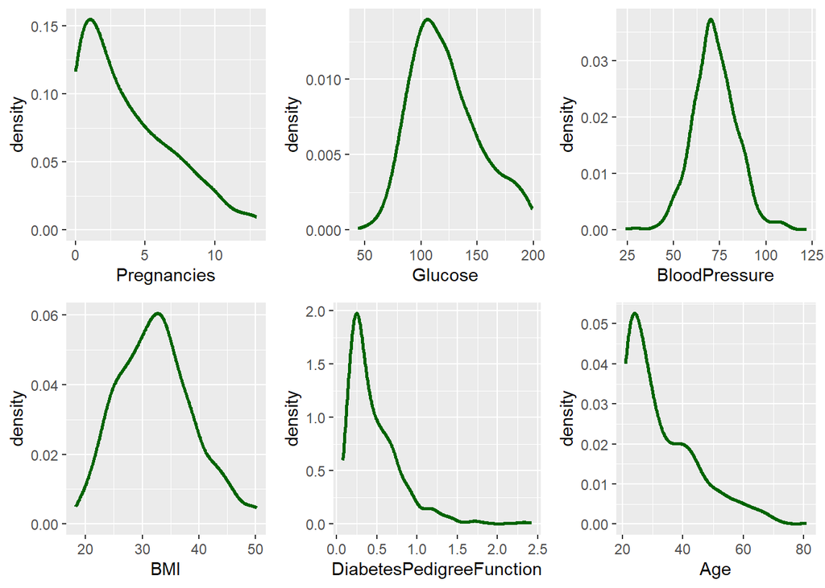

```r
plots <- lapply(names(diabetes[,1:6]), function(var_x){
  p <-
    ggplot(diabetes) +
    aes_string(var_x)

  if(is.numeric(diabetes[[var_x]])) {
    p <- p + geom_density(lwd=1, color="darkgreen")

  } else {
    p <- p + geom_bar(fill="darkred")
  }

})

plot_grid(plotlist = plots)
```

### 6.12.5 Hasil Standarisasi

Plot Sebaran Hasil Standarisasi

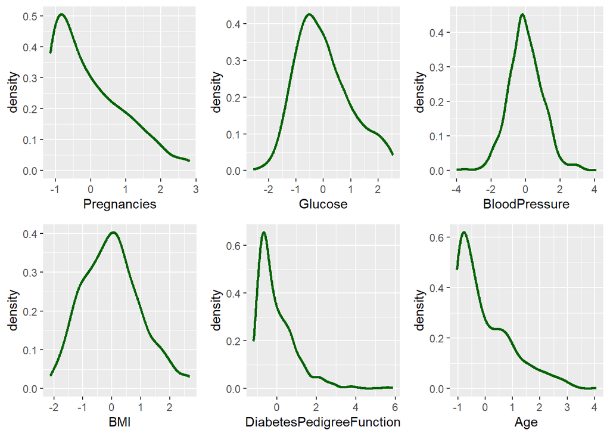

```r
plots <- lapply(names(standardized), function(var_x){
  p <-
    ggplot(standardized) +
    aes_string(var_x) +
    geom_density(lwd=1, color="darkgreen")
})

plot_grid(plotlist = plots)
```

### 6.12.6 Hasil Normalisasi

Plot Sebaran Hasil Normalisasi

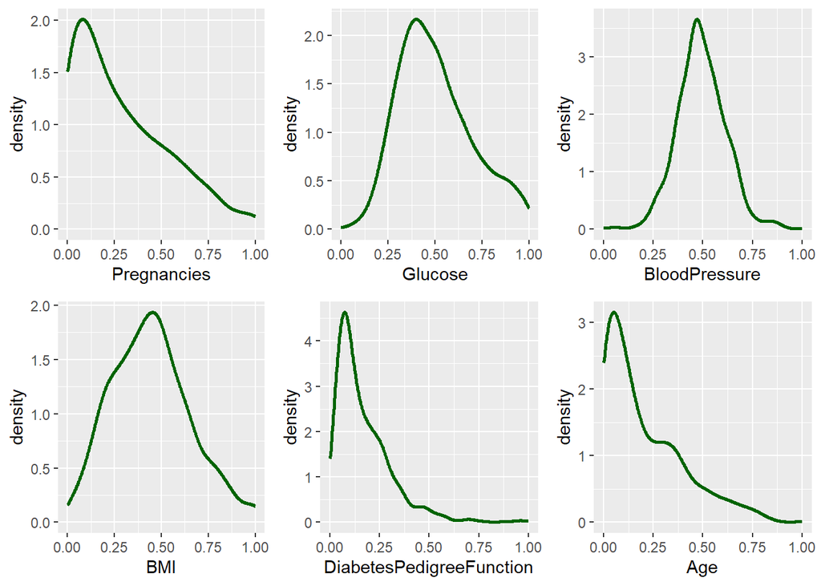

```r
plots <- lapply(names(normalized), function(var_x){
  p <-
    ggplot(normalized) +
    aes_string(var_x) +
    geom_density(lwd=1, color="darkgreen")
})

plot_grid(plotlist = plots)
```

## 6.13 Transformasi Box-Cox

Transformasi umumnya digunakan untuk merubah sebaran suatu feature ketika feature tersebut tidak normal sehingga menjadi mendekati sebaran normal.

Box-Cox Transformation biasanya dilakukan pada variabel dependen (Y) dalam analisis regresi atau analisis varian (ANOVA). Ini dilakukan untuk memastikan bahwa variabel dependen memiliki distribusi yang lebih dekat dengan normal sehingga asumsi distribusi normal dalam model regresi atau ANOVA terpenuhi.

Transformasi ini juga dapat digunakan pada variabel independen (X) jika diperlukan, tergantung pada distribusi data dan tujuan analisis. Namun, transformasi pada variabel independen lebih jarang dilakukan karena memiliki implikasi terhadap interpretasi model akhir.

```r
preprocessParams <- preProcess(diabetes[,1:6], method=c("BoxCox"))
print(preprocessParams)
```

```
## Created from 768 samples and 5 variables
##
## Pre-processing:
##   - Box-Cox transformation (5)
##   - ignored (0)
##
## Lambda estimates for Box-Cox transformation:
## 0.1, 0.9, 0.3, -0.1, -1.1
```

```r
transformed <- predict(preprocessParams, diabetes[,1:6])
summary(transformed)
```

```
##   Pregnancies        Glucose      BloodPressure         BMI
##  Min.   : 0.000   Min.   :3.784   Min.   : 24.00   Min.   :4.626
##  1st Qu.: 1.000   1st Qu.:4.603   1st Qu.: 64.00   1st Qu.:5.676
##  Median : 3.000   Median :4.762   Median : 72.00   Median :6.095
##  Mean   : 3.783   Mean   :4.770   Mean   : 72.25   Mean   :6.087
##  3rd Qu.: 6.000   3rd Qu.:4.943   3rd Qu.: 80.00   3rd Qu.:6.482
##  Max.   :13.000   Max.   :5.293   Max.   :122.00   Max.   :7.462
##  DiabetesPedigreeFunction      Age
##  Min.   :-2.5510          Min.   :0.8772
##  1st Qu.:-1.4116          1st Qu.:0.8815
##  Median :-0.9875          Median :0.8867
##  Mean   :-0.9599          Mean   :0.8874
##  3rd Qu.:-0.4680          3rd Qu.:0.8938
##  Max.   : 0.8838          Max.   :0.9019
```

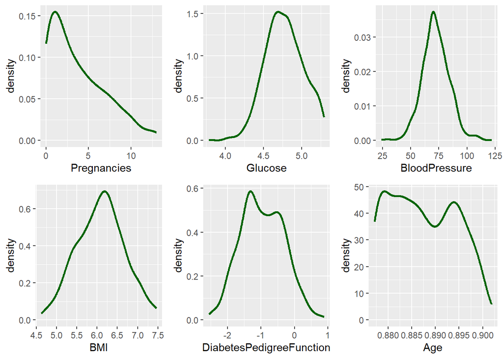

```r
plots <- lapply(names(transformed), function(var_x){
  p <-
    ggplot(transformed) +
    aes_string(var_x)  +
    geom_density(lwd=1, color="darkgreen")
})

plot_grid(plotlist = plots)
```